# Evaluation Module 4/5

DUBii 2020

Matthieu DUCHMANN

2020-08-30

# Enoncé

## DU-Bii 2020 : Examen final Modules 4 et 5

Nous allons vous faire faire un analyse simple, de données de reséquençage d’un génome bactérien. Les données sont issues de cet article : “Complete Genome Sequences of 13 Bacillus subtilis Soil Isolates for Studying Secondary Metabolite Diversity” (doi:10.1128/MRA.01406-19)

## Objectif :

Nous alons vous demander de faire une première analyse de ces données, et de nous la rendre sous la forme d’un rapport qui trace l’ensemble des étapes suivies. Ce rapport devra être mis à nôtre disposition dans un dépôt public GitHub. Les analyses devront pouvoir être rejouées sur le cluster de l’IFB.

Données d’entrées : - Identifiant du run : SRR10390685 - Génome de référence : NC_000964 - Gff https://ftp.ncbi.nlm.nih.gov/genomes/all/GCF/000/009/045/GCF_000009045.1_ASM904v1/GCF_000009045.1_ASM904v1_genomic.gff.gz - Fasta https://ftp.ncbi.nlm.nih.gov/genomes/all/GCF/000/009/045/GCF_000009045.1_ASM904v1/GCF_000009045.1_ASM904v1_genomic.fna.gz

## Consignes :

Détailler les différentes étapes dans un rapport HTML ou PDF (généré via un Rmd ou autre).

- Téléchargement des données depuis les banques publiques
- Contrôle qualité des données brutes (reads)
  - La qualité des bases vous paraît-elle satisfaisante ? Pourquoi ?
  - Quelle est la profondeur de séquençage (calculée par rapport à la taille du génome de référence) ?
- Nettoyage des reads
  - Quel pourcentage de reads sont filtrés et pourquoi ?
- Alignement des reads contre le génome de reférence
  - Quel est le % de reads pairés alignés ?
- Extraire dans un fichier BAM les reads chevauchant à au moins 50% le gène trmNF

## Informations devant figurer dans le rapport

- Présentation (par exemple à l’aide de la commande `tree`) de l’organisation du repretoire du projet
- Justification des paramètres utilisés
- Analyse succinte des résultats obtenus après chaque outil lancé (figures, tableaux ou texte)

> N’oubliez pas les informations nécessaires à la reproductibilité des analyses !!

# Création et organisation du répertoire de travail

```bash
mkdir -p eval_M4/{data/raw,data/ref,data/outputs,data/reports,scripts,analysis}
```

*data* sera le dossier qui va contenir les données du projet, dans les sous-dossiers suivant : - raw : raw data des données de séquençage - ref : pour le génome de référence (fasta) et son annotation (gff) - output : données produites

*scripts* contiendra le script de l’analyse, et le rapport Rmd suivant.

*analysis* contiendra les données pour ce rapport, et dans la vraie vie les données pour publication (i.e images, tables)

Le repertoire de travail sera donc eval_M4/.

```
eval_M4
+-- analysis
+-- data
|   +-- outputs
|   +-- raw
|   +-- ref
|   \-- reports
\-- scripts
```

# Téléchargement des données.

## Téléchargement des références.

### Génome de référence (FASTA).

```bash
srun  wget -O data/ref/GCF_000009045.1_ASM904v1_genomic.fna.gz https://ftp.ncbi.nlm.nih.gov/genomes/all/GCF/000/009/045/GCF_000009045.1_ASM904v1/GCF_000009045.1_ASM904v1_genomic.fna.gz
```

### Annotations (GFF).

```bash
srun  wget -O data/ref/GCF_000009045.1_ASM904v1_genomic.gff.gz https://ftp.ncbi.nlm.nih.gov/genomes/all/GCF/000/009/045/GCF_000009045.1_ASM904v1/GCF_000009045.1_ASM904v1_genomic.gff.gz
```

## Téléchargement des raw data.

Sur le site SRA, on peut obtenir les informations suivantes avec le numéro d’accès.

- SRX7091090: Bacillus subtilis WGS illumina lib strain P5_B1 1 ILLUMINA (NextSeq 500) run: 7.1M spots, 2.1G bases, 862.4Mb downloads
- Design: DNA was extracted with the GeneMATRIX Bacterial & Yeast Genomic DNA Purification Kit. An Illumina library was made with the nextera library kit before sequencing on an Illumina NextSeq machine
- Organism: Bacillus subtilis
- Library:
  - Name: illumina_P5_B1
  - Instrument: NextSeq 500
  - Strategy: WGS
  - Source: GENOMIC
  - Selection: RANDOM
  - Layout: PAIRED

Pour télécharger les données, on utilise la fonction fasterq-dump du module sra-tools avec les options suivantes :

- –split-files car il s’agit d’un séquençage paired-end
- –progress pour suivre l’évolution du téléchargement
- –outdir permet de diriger les fichiers téléchargés vers le répertoire des raw data

– threads 8 permet d’utiliser le multi-threading pour augmenter la vitesse de téléchargement.

```bash
module load sra-tools/2.10.3

srun --cpus-per-task 8 fasterq-dump --split-files --progres --outdir data/raw --threads 8  SRR10390685
```

# Contrôles qualité

## Lancement de l’analyse.

On utilise le logiciel fastqc pour évaluer la qualité des Fastq téléchargés. On utiliser le multithreading pour augmenter la vitesse d’execution.

```bash
module load fastqc/0.11.9

srun --cpus-per-task 8 fastqc data/raw/SRR10390685_1.fastq --outdir data/reports --threads 8
```

Le rapport MultiQC est accessible [ici](https://md-paris.github.io/EvalM4/multiqc_report_1.html).

## Interprétation.

La qualité des bases me parait satisfaisante, car le Phred score reste élevé (faible risque d’erreur, > 30), y compris en fin de séquençage.

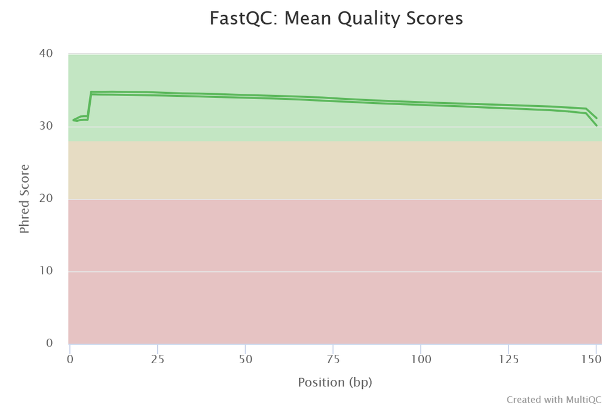

Plot

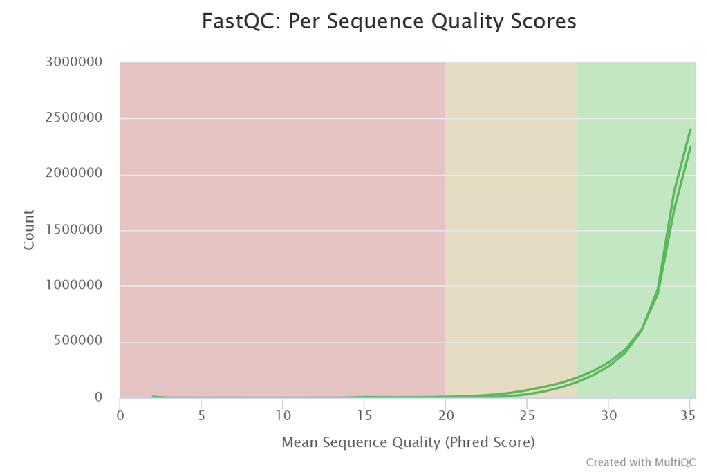

Plot

## Calcul de la profondeur théorique.

Pour définir la profondeur théorique, on se fonde sur les données issues du fastqc :

$$Profondeur\ théorique = \frac{nb\ reads\ R1\ *longueur\ moyenne\ R1+nb\ reads\ R2 * longueur\ moyenne\ R2 }
{taille\ du\ génome}$$
$$= \frac{ 2*7,066,055*150}
{4,215,606} = 502 X$$

La profondeur semble correcte, mais dépendra des analyses que nous souhaiterons réaliser ultérieurement.

# Nettoyage des reads

## Réalisation du nettoyage

Nous allons nettoyer les fichiers FASTQ avec l’outil fastp, qui process les fastq en fonction des rapports fastqc.

- -l permet de filtrer les petits reads sur une taille minimum, ici 100 bp
- -w permet d’utiliser 8 threads

```bash
module load fastp/0.20.0
srun --cpus-per-task 8 fastp --in1 data/raw/SRR10390685_1.fastq --in2 data/raw/SRR10390685_2.fastq \
      -l 100  \
      --out1 data/outputs/SRR10390685_1.preprocessed.fastq --out2 data/outputs/SRR10390685_2.preprocessed.fastq \
      --unpaired1 data/outputs/SRR10390685_1.unpaired.fastq --unpaired2 data/outputs/SRR10390685_2.unpaired.fastq \
      -w 8 \
      -j data/reports/fastp.json -h  data/reports/fastp.html
```

Le rapport MultiQC est accessible [ici](https://md-paris.github.io/EvalM4/multiqc_report_1.html).

## Efficacité du nettoyage

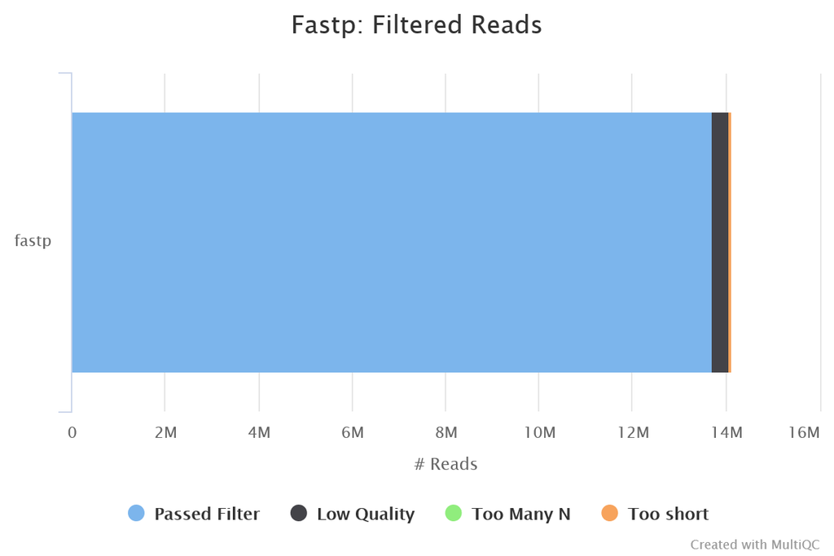

407,328 (2.9%) reads ont été filtrés par Fastp :

- 366,402 (2.6%) reads ont été filtrés en raison d’une qualité insuffisante,
- 4,076 (< 0.1%) reads ont été filtrés en raison d’un trop grand nombre de base incertaine (N),
- 36,850 (0.3%) reads ont été filtrés en raison d’une taille insuffisante.

Comme attendu, peu de reads ont été exclus car le séquençage était de qualité suffisante.

# Alignement des reads contre le génome de référence.

## Création de l’index BWA

On crée tout d’abord l’index pour pouvoir aligner les fastq.

```bash
module load bwa/0.7.17

srun bwa index data/ref/GCF_000009045.1_ASM904v1_genomic.fna.gz
```

## Alignement

Puis on procède à l’alignement avec la fonction bwa mem. - -t permet d’utiliser le multi-threading

- samtools view permet de générer un format BAM standard (-b) avec entête (-h) et ignore la compatibilité avec des versions de Samtools antérieure (-S)

```bash
module load samtools/1.9

srun --cpus-per-task=33 bwa mem data/ref/GCF_000009045.1_ASM904v1_genomic.fna.gz data/outputs/SRR10390685_1.preprocessed.fastq data/outputs/SRR10390685_2.preprocessed.fastq -t 32 | samtools view -hbS > data/outputs/SRR10390685.bam
```

## Evaluation de la qualité de l’alignement

On utilise samtools flagstat, et on redirige l’output SRR10390685.flagstat.txt pour qu’il soit identifié par multiQC.

```bash
module load multiqc/1.9

srun samtools flagstat data/outputs/SRR10390685.bam > data/reports/SRR10390685.flagstat.txt

srun multiqc data/reports/ --outdir data/reports
```

Le rapport multiQC est disponible [ici](https://md-paris.github.io/EvalM4/multiqc_report_1.html).

Samtools flagstat rapporte :

13743328 + 0 in total (QC-passed reads + QC-failed reads)

0 + 0 secondary

18546 + 0 supplementary

0 + 0 duplicates

12990720 + 0 mapped (94.52% : N/A)

13724782 + 0 paired in sequencing

6862391 + 0 read1

6862391 + 0 read2

12908996 + 0 properly paired (94.06% : N/A)

12932150 + 0 with itself and mate mapped

40024 + 0 singletons (0.29% : N/A)

0 + 0 with mate mapped to a different chr

0 + 0 with mate mapped to a different chr (mapQ>=5)

On peut en déduire que 12932150 reads ont été correctement mappés avec son mate, soit 94.1%, ce qui est très satisfaisant.

# Extraction des reads chevauchant au moins 50% le gène trmNF.

## Extraction du gff.gz

Un utilise gunzip pour extraire le fichier gff.

```bash
srun gunzip data/ref/GCF_000009045.1_ASM904v1_genomic.gff.gz
```

## Extraction de la ligne du gff concernant le gène trmNF

Grace à grep, on isole les lignes contenant les informations concernant le gène trmNF, puis grace à awk, on sélectionne la ligne qui contient les informations du gène (information dans la 3ème colonne).

```bash
srun grep "trmNF" data/ref/GCF_000009045.1_ASM904v1_genomic.gff |\
 awk '$3=="gene"' > data/outputs/trmNF_gene.gff3
```

## Sorting et indexing du bam

On trie le bam avec la fonction samtools sort, et on l’index avec la fonction samtools index.

```bash
srun samtools sort data/outputs/SRR10390685.bam -o data/outputs/SRR10390685.sorted.bam

srun samtools index data/outputs/SRR10390685.sorted.bam
```

## Extraction des reads qui recouvrent trmNF > 50% de leur longueur

On extrait l’intersect entre le bam trié et indexé et le gff, en utilisant bedtools intersect.

- -f 0.50 permet de retenir les reads qui mappent au moins 50% de leur longueur sur le gène

```bash
module load bedtools/2.29.2

srun bedtools intersect -a data/outputs/SRR10390685.sorted.bam \
-b data/outputs/trmNF_gene.gff3 \
-f 0.50 >  data/outputs/SRR10390685.readsmappingtrmNF.bam
```

Puis pour compter le nombre de reads retenus, on utilise la fonction samtools view, avec l’option -c qui permet de compter le nombre de reads.

```bash
srun samtools view -c data/outputs/SRR10390685.readsmappingtrmNF.bam
```

Il y a donc 2840 reads qui mappent trmNF sur au moins 50% de leur longueur.